# Complement component C6

Fold-switch pair **3t5oA_4a5wB** — **3t5oA** vs **4a5wB**

Homo sapiens

## Figure 1: Phylogenetic tree with per-cluster fold-preference heatmap.

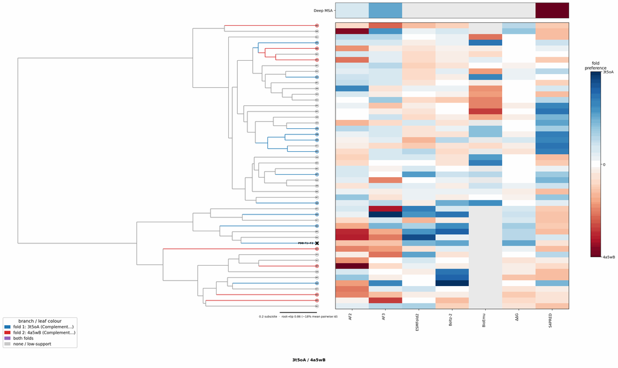

## Figure 2: Aligned overlay (both folds superposed)

The single fold-switching chain of each fold superposed by TM-align; waters hidden, any ligand shown as green sticks. Grey = structurally conserved core, colour = divergent (fold-switching) region.

3t5oA (Complement component C6) · monomer4a5wB (Complement component C6) · dimerLigand BGC|CD|FUC|FUL|MAN|NAG (bound to 3t5oA), Ligand FUC|MAN|NAG (bound to 4a5wB)

TM-score: 0.587 · Trigger class: protein_binding

Aligned overlay

## Figure 3: The two folds, side by side

Each fold is coloured by per-residue Cα deviation between the two superposed structures: grey ≈ conserved core, full colour = structurally divergent (fold-switching) region.

3t5oA (Complement component C6)

4a5wB (Complement component C6)

0 Å5≥10 Å

3t5oA (Complement component C6)

4a5wB (Complement component C6)

## Figure 4: Best-cluster predicted contact maps over the two true folds.

Predicted contact maps (MSA-Transformer) for the clusters best matching each fold, over the true contacts of fold 1 (upper triangle) and fold 2 (lower). Divergent contacts between clusters are the contact-level signature of fold-switching.

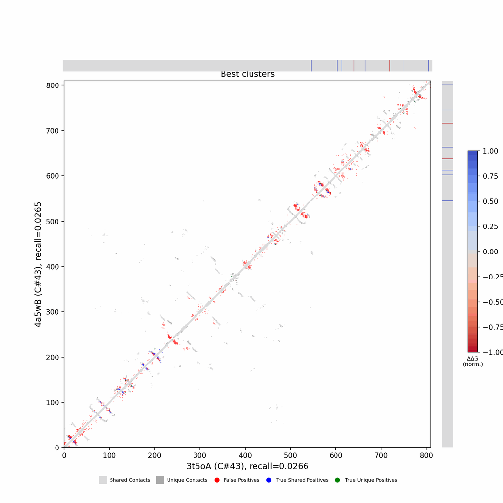

## Figure 5: Per-residue ΔΔG fold-preference contribution

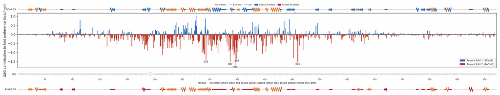

**More figures**

## Figure 6: Deep-MSA contact map panel / Best clusters contact map panel

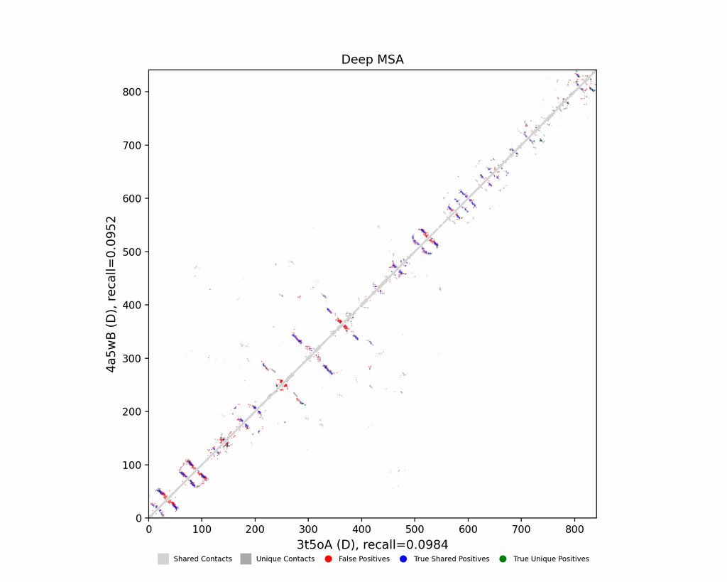

Deep-MSA contact map panel

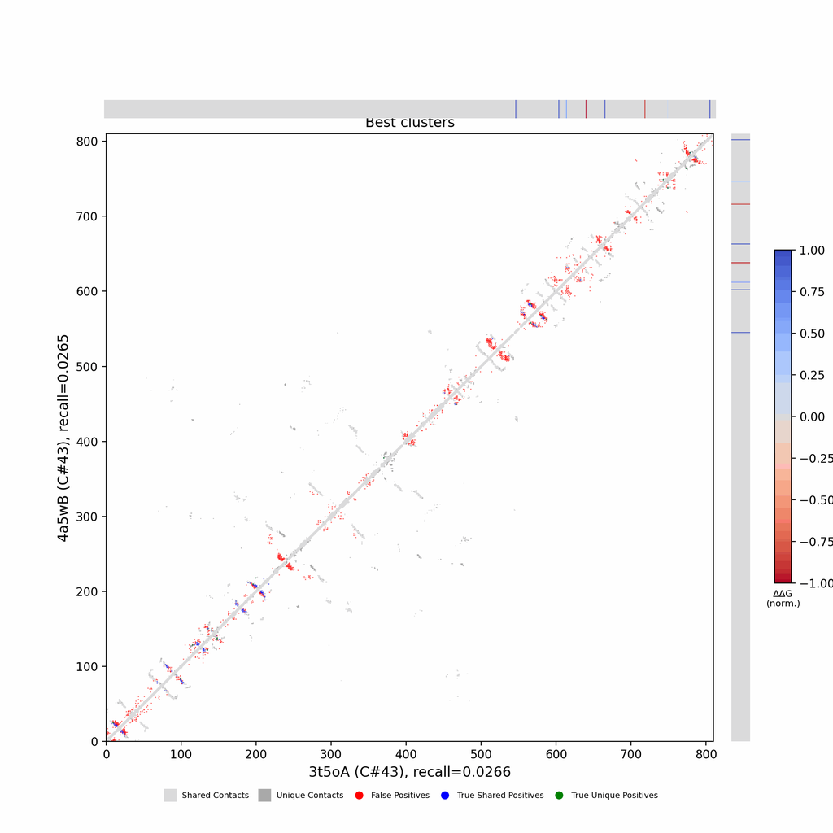

Best clusters contact map panel

## Figure 7: All clusters contact-map mosaic (small multiples).

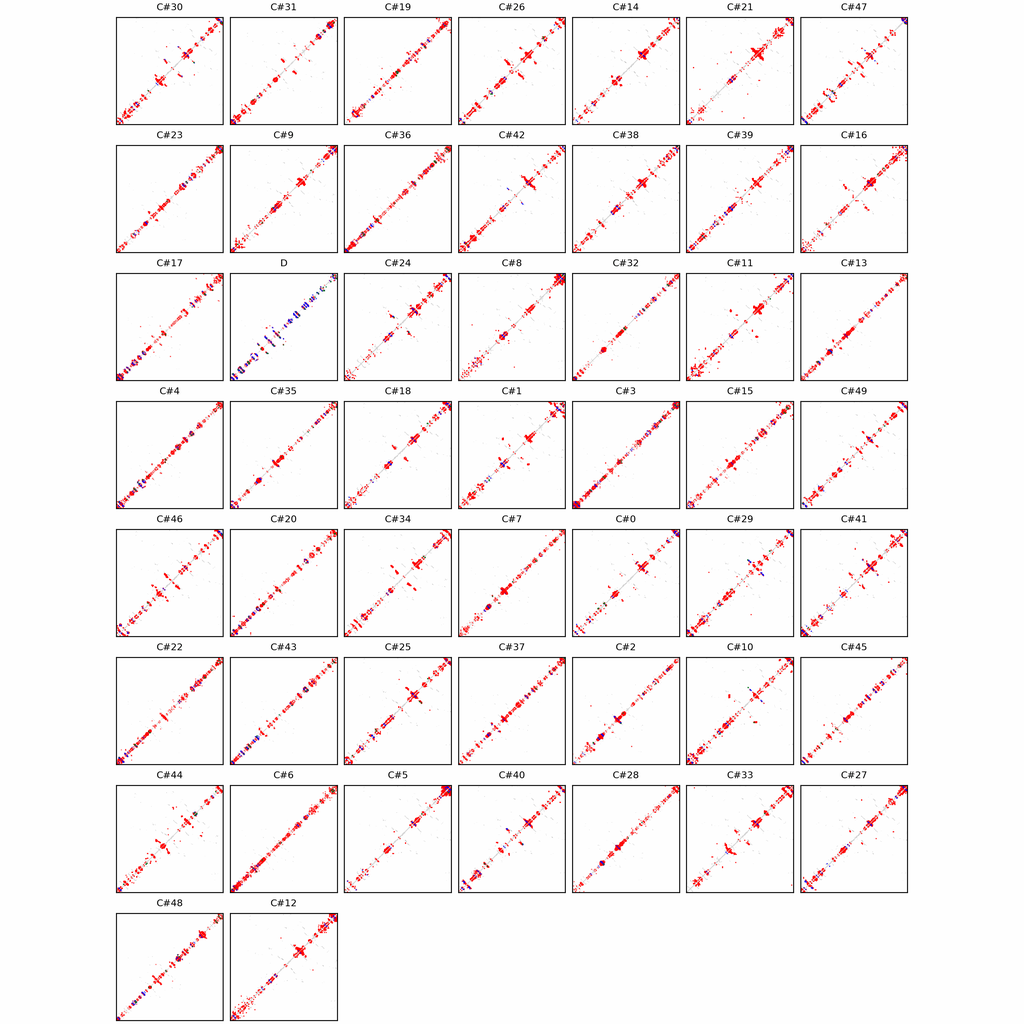

## Figure 8: Phylo null: tree with shuffled cluster fold labels.

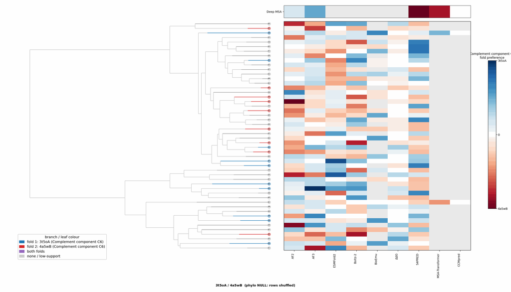

## Cluster metrics table

Per-cluster metrics underlying the figures above.

| cluster | n | neff | AF2_TM1 | AF2_TM2 | AF3_TM1 | AF3_TM2 | RE-MSAT-COM | RE-MSAT1 | RE-MSAT2 | ESM_SEQIDS | ESM_TM1 | ESM_TM2 | ΔΔG_Bias | ΔΔG_Bias_std | ΔΔG_frac_F1 | Boltz2_pref | S4PRED_pref | CCMpred_pref | BioEmu_pref |
| --- | --- | --- | --- | --- | --- | --- | --- | --- | --- | --- | --- | --- | --- | --- | --- | --- | --- | --- | --- |
| Deep | - | - | 0.6 | 0.6 | 0.6 | 0.57 | 0.23 | 0.18 | 0.19 | - | - | - | - | - | - | - | -0.08 | 0.0 | - |
| 000 | 251.0 | 83.0 | 0.17 | 0.16 | 0.17 | 0.15 | 0.01 | 0.01 | 0.01 | 001; 001; 003; 003; 002; 002; 005; 005; 007; 006 | 0.40 ± 0.06 | 0.37 ± 0.06 | -75.33 | 17.23 | 0.0 | 0.04 | -0.05 | 0.0 | 0.01 |
| 001 | 189.0 | 38.0 | 0.14 | 0.12 | 0.14 | 0.13 | 0.01 | 0.01 | 0.01 | 001; 001; 003; 003; 002; 002; 006; 006; 009; 009 | 0.45 ± 0.06 | 0.43 ± 0.05 | -70.7 | 8.71 | 0.0 | 0.0 | -0.08 | 0.0 | 0.0 |
| 002 | 186.0 | 60.0 | 0.14 | 0.14 | 0.19 | 0.18 | 0.0 | 0.0 | 0.0 | - | - | - | -88.08 | 35.4 | 0.0 | -0.02 | -0.08 | - | - |
| 003 | 179.0 | 8.0 | 0.12 | 0.13 | 0.22 | 0.23 | 0.01 | 0.01 | 0.0 | - | - | - | -20.17 | 16.05 | 0.1 | 0.04 | -0.07 | - | - |
| 004 | 169.0 | 36.0 | 0.14 | 0.15 | 0.22 | 0.19 | 0.01 | 0.01 | 0.01 | - | - | - | -38.5 | 20.21 | 0.0 | 0.04 | -0.08 | - | - |
| 005 | 156.0 | 51.0 | 0.19 | 0.18 | 0.35 | 0.35 | 0.01 | 0.0 | 0.0 | - | - | - | -71.42 | 16.51 | 0.0 | -0.0 | -0.05 | - | - |
| 006 | 154.0 | 10.0 | 0.12 | 0.15 | 0.14 | 0.16 | 0.0 | 0.0 | 0.0 | - | - | - | -42.29 | 32.79 | 0.0 | 0.06 | -0.08 | - | - |
| 007 | 147.0 | 20.0 | 0.14 | 0.18 | 0.16 | 0.17 | 0.01 | 0.01 | 0.01 | - | - | - | -78.92 | 24.58 | 0.0 | -0.01 | -0.07 | - | - |
| 008 | 144.0 | 18.0 | 0.14 | 0.14 | 0.16 | 0.16 | 0.01 | 0.01 | 0.01 | - | - | - | -69.36 | 12.25 | 0.0 | -0.0 | -0.04 | - | 0.0 |
| 009 | 143.0 | 12.0 | 0.15 | 0.15 | 0.15 | 0.15 | 0.0 | 0.0 | 0.0 | - | - | - | -61.17 | 16.95 | 0.0 | 0.02 | -0.0 | - | - |
| 010 | 130.0 | 28.0 | 0.13 | 0.14 | 0.15 | 0.16 | 0.0 | 0.0 | 0.0 | - | - | - | -73.58 | 17.7 | 0.0 | -0.01 | -0.01 | - | - |
| 011 | 123.0 | 34.0 | 0.14 | 0.16 | 0.14 | 0.14 | 0.0 | 0.0 | 0.0 | - | - | - | -70.74 | 9.42 | 0.0 | -0.0 | -0.08 | - | 0.0 |
| 012 | 120.0 | 17.0 | 0.14 | 0.14 | 0.16 | 0.18 | 0.01 | 0.0 | 0.0 | - | - | - | -79.61 | 11.16 | 0.0 | -0.01 | 0.0 | - | 0.0 |
| 013 | 114.0 | 35.0 | 0.14 | 0.14 | 0.16 | 0.19 | 0.01 | 0.01 | 0.01 | - | - | - | -75.24 | 34.98 | 0.0 | -0.01 | -0.03 | - | - |
| 014 | 109.0 | 15.0 | 0.14 | 0.14 | 0.16 | 0.14 | 0.0 | 0.0 | 0.0 | - | - | - | -70.58 | 22.35 | 0.0 | -0.02 | -0.03 | - | -0.0 |
| 015 | 103.0 | 34.0 | 0.15 | 0.17 | 0.2 | 0.2 | 0.0 | 0.0 | 0.0 | - | - | - | -89.67 | 31.47 | 0.0 | 0.0 | -0.06 | - | - |
| 016 | 102.0 | 17.0 | 0.15 | 0.14 | 0.16 | 0.16 | 0.0 | 0.0 | 0.0 | - | - | - | -67.06 | 17.88 | 0.0 | 0.01 | -0.04 | - | -0.0 |
| 017 | 99.0 | 28.0 | 0.16 | 0.17 | 0.18 | 0.18 | 0.01 | 0.0 | 0.01 | - | - | - | -52.82 | 19.06 | 0.0 | -0.0 | -0.08 | - | - |
| 018 | 97.0 | 24.0 | 0.18 | 0.17 | 0.44 | 0.46 | 0.02 | 0.01 | 0.01 | - | - | - | -76.25 | 15.81 | 0.0 | 0.01 | -0.02 | - | - |
| 019 | 97.0 | 22.0 | 0.15 | 0.16 | 0.24 | 0.2 | 0.0 | 0.0 | 0.0 | - | - | - | -72.63 | 27.59 | 0.0 | 0.07 | -0.02 | - | - |
| 020 | 95.0 | 32.0 | 0.16 | 0.15 | 0.25 | 0.2 | 0.01 | 0.01 | 0.01 | - | - | - | -52.22 | 14.73 | 0.0 | 0.05 | -0.08 | - | - |
| 021 | 92.0 | 4.0 | 0.14 | 0.14 | 0.14 | 0.13 | 0.0 | 0.0 | 0.0 | - | - | - | -87.32 | 9.86 | 0.0 | -0.01 | -0.0 | - | - |
| 022 | 89.0 | 21.0 | 0.16 | 0.15 | 0.17 | 0.21 | 0.0 | 0.0 | 0.0 | - | - | - | -52.79 | 10.23 | 0.0 | 0.01 | -0.08 | - | - |
| 023 | 87.0 | 12.0 | 0.12 | 0.14 | 0.18 | 0.2 | 0.0 | 0.0 | 0.0 | - | - | - | -66.9 | 34.23 | 0.0 | 0.01 | -0.08 | - | - |
| 024 | 77.0 | 15.0 | 0.16 | 0.15 | 0.18 | 0.17 | 0.0 | 0.0 | 0.0 | - | - | - | -68.54 | 18.28 | 0.0 | -0.0 | -0.06 | - | 0.01 |
| 025 | 77.0 | 30.0 | 0.16 | 0.16 | 0.14 | 0.14 | 0.02 | 0.01 | 0.01 | - | - | - | -73.86 | 24.83 | 0.0 | 0.0 | 0.0 | - | -0.0 |
| 026 | 77.0 | 29.0 | 0.16 | 0.16 | 0.19 | 0.21 | 0.0 | 0.0 | 0.0 | - | - | - | -79.24 | 7.24 | 0.0 | 0.0 | -0.0 | - | -0.0 |
| 027 | 73.0 | 35.0 | 0.14 | 0.13 | 0.16 | 0.16 | 0.0 | 0.0 | 0.0 | - | - | - | -73.1 | 9.49 | 0.0 | 0.02 | -0.03 | - | 0.0 |
| 028 | 70.0 | 2.0 | 0.16 | 0.15 | 0.2 | 0.2 | 0.01 | 0.0 | 0.01 | - | - | - | -82.08 | 23.57 | 0.0 | 0.05 | -0.08 | - | - |
| 029 | 63.0 | 17.0 | 0.16 | 0.15 | 0.16 | 0.15 | 0.01 | 0.01 | 0.02 | - | - | - | -76.84 | 8.8 | 0.0 | 0.0 | -0.03 | - | 0.0 |
| 030 | 61.0 | 23.0 | 0.17 | 0.15 | 0.16 | 0.17 | 0.01 | 0.01 | 0.01 | - | - | - | -73.28 | 13.9 | 0.0 | 0.0 | -0.05 | - | -0.0 |
| 031 | 61.0 | 19.0 | 0.15 | 0.13 | 0.16 | 0.14 | 0.02 | 0.01 | 0.01 | - | - | - | -72.9 | 11.38 | 0.0 | 0.0 | -0.08 | - | -0.0 |
| 032 | 60.0 | 14.0 | 0.12 | 0.14 | 0.17 | 0.18 | 0.0 | 0.0 | 0.0 | - | - | - | -98.94 | 12.77 | 0.0 | -0.0 | -0.07 | - | - |
| 033 | 59.0 | 8.0 | 0.18 | 0.17 | 0.18 | 0.18 | 0.0 | 0.0 | 0.0 | - | - | - | -75.79 | 6.57 | 0.0 | -0.0 | -0.08 | - | -0.0 |
| 034 | 59.0 | 22.0 | 0.17 | 0.16 | 0.15 | 0.14 | 0.0 | 0.0 | 0.0 | - | - | - | -70.12 | 11.98 | 0.0 | 0.01 | -0.04 | - | 0.01 |
| 035 | 54.0 | 15.0 | 0.12 | 0.12 | 0.17 | 0.2 | 0.0 | 0.0 | 0.0 | - | - | - | -92.88 | 16.21 | 0.0 | -0.02 | -0.07 | - | - |
| 036 | 51.0 | 8.0 | 0.14 | 0.16 | 0.16 | 0.19 | 0.0 | 0.0 | 0.0 | - | - | - | -46.33 | 30.92 | 0.0 | 0.0 | -0.04 | - | - |
| 037 | 40.0 | 15.0 | 0.14 | 0.16 | 0.19 | 0.19 | 0.01 | 0.01 | 0.01 | - | - | - | -85.16 | 20.37 | 0.0 | 0.0 | -0.06 | - | - |
| 038 | 39.0 | 11.0 | 0.13 | 0.13 | 0.17 | 0.16 | 0.01 | 0.01 | 0.01 | - | - | - | -77.24 | 18.87 | 0.0 | -0.01 | -0.0 | - | 0.0 |
| 039 | 39.0 | 13.0 | 0.14 | 0.15 | 0.16 | 0.16 | 0.03 | 0.02 | 0.02 | - | - | - | -73.67 | 8.16 | 0.0 | -0.01 | -0.08 | - | 0.01 |
| 040 | 38.0 | 18.0 | 0.14 | 0.15 | 0.19 | 0.2 | 0.01 | 0.01 | 0.01 | - | - | - | -75.36 | 9.54 | 0.0 | -0.0 | -0.05 | - | 0.0 |
| 041 | 37.0 | 14.0 | 0.14 | 0.13 | 0.17 | 0.16 | 0.01 | 0.01 | 0.01 | - | - | - | -77.77 | 9.8 | 0.0 | -0.01 | -0.06 | - | 0.0 |
| 042 | 34.0 | 15.0 | 0.14 | 0.14 | 0.17 | 0.17 | 0.0 | 0.0 | 0.0 | - | - | - | -71.16 | 11.21 | 0.0 | -0.0 | -0.05 | - | 0.0 |
| 043 | 34.0 | 14.0 | 0.15 | 0.15 | 0.17 | 0.2 | 0.05 | 0.04 | 0.04 | - | - | - | -45.51 | 29.15 | 0.0 | -0.02 | -0.08 | - | - |
| 044 | 33.0 | 19.0 | 0.12 | 0.13 | 0.16 | 0.16 | 0.0 | 0.0 | 0.0 | - | - | - | -74.31 | 20.5 | 0.0 | -0.01 | -0.08 | - | 0.01 |
| 045 | 30.0 | 20.0 | 0.14 | 0.12 | 0.18 | 0.18 | 0.02 | 0.01 | 0.02 | - | - | - | -103.32 | 19.02 | 0.0 | 0.06 | -0.08 | - | - |
| 046 | 27.0 | 16.0 | 0.16 | 0.16 | 0.17 | 0.17 | 0.02 | 0.02 | 0.02 | - | - | - | -78.83 | 9.55 | 0.0 | 0.01 | -0.08 | - | 0.0 |
| 047 | 17.0 | 12.0 | 0.18 | 0.16 | 0.15 | 0.16 | 0.04 | 0.03 | 0.04 | - | - | - | -77.22 | 8.32 | 0.0 | -0.0 | -0.02 | - | 0.0 |
| 048 | 15.0 | 13.0 | 0.21 | 0.24 | 0.33 | 0.3 | 0.02 | 0.02 | 0.01 | - | - | - | -32.22 | 22.82 | 0.0 | 0.01 | -0.08 | - | - |
| 049 | 14.0 | 10.0 | 0.14 | 0.14 | 0.19 | 0.18 | 0.03 | 0.02 | 0.02 | - | - | - | -80.09 | 7.03 | 0.0 | -0.0 | -0.02 | - | -0.0 |